# Diabetes Prediction

Vadiwoo Karuppiah

2023-08-01

## Introduction

### Diabetes Prediction Analysis

Diabetes is a chronic condition affecting millions worldwide and is caused by elevated blood glucose levels. Early detection and accurate prediction of diabetes can significantly improve patient outcomes through personalized care. This analysis aim to explore and predict diabetes cases using a comprehensive dataset containing various patient attributes, including age, gender, BMI (Body Mass Index), blood glucose levels, and HbA1c levels. The data used in this analysis is sourced from Kaggle website. [Kaggle dataset for diabetes prediction](https://www.kaggle.com/datasets/iammustafatz/diabetes-prediction-dataset)

The objective of this analysis is to construct robust prediction models based on decision trees, leveraging the power of two popular R packages, `party` and `rpart`. To achieve our goal, the following steps are performed:

Data Exploration: The analysis will begin by loading and inspecting the dataset to understand its structure and basic statistics. This step will help us identify missing values, distributions of features, and the prevalence of diabetes cases within the dataset.

Feature Visualization: Through a series of insightful plots, including histograms, bar plots, and box plots, the analysis visually explores the distribution and relationships between individual features and diabetes occurrence. These visualizations will provide a deeper understanding of how different attributes relate to the target variable.

Data Preprocessing: Before building the prediction models, we will preprocess the data by converting the target class into factors and potentially handling categorical variables.

Decision Tree Construction: Leveraging the party and rpart packages, we will construct two sets of decision trees. The party package offers conditional inference trees, while the rpart package implements the classic CART algorithm. By comparing the two approaches, we can evaluate which model best fits our dataset and provides meaningful predictive insights.

Model Evaluation: To ensure the reliability and accuracy of our prediction models, we will partition the data into training and testing sets. We will then evaluate the models’ performance using metrics such as misclassification errors to assess their predictive capabilities.

Through this diabetes prediction analysis, we aim to contribute to the growing field of medical data analysis, potentially aiding healthcare practitioners in early detection and tailored interventions for patients at risk of diabetes. Moreover, the interpretability of decision trees will enable us to understand the factors driving the predictions, paving the way for more informed and targeted healthcare strategies.

#### Loading Libraries

```r
# Load necessary libraries
invisible(library(ggplot2))
invisible(library(corrplot))
invisible(library(party))
invisible(library(rpart))
invisible(library(rpart.plot))
invisible(library(dplyr))
invisible(library(caret))
invisible(library(randomForest))
```

#### Data Summary

```r
# Load the data
data <- read.csv("diabetes_prediction_dataset.csv")

# View data summary
summary(data)
```

```
##     gender               age         hypertension     heart_disease
##  Length:100000      Min.   : 0.08   Min.   :0.00000   Min.   :0.00000
##  Class :character   1st Qu.:24.00   1st Qu.:0.00000   1st Qu.:0.00000
##  Mode  :character   Median :43.00   Median :0.00000   Median :0.00000
##                     Mean   :41.89   Mean   :0.07485   Mean   :0.03942
##                     3rd Qu.:60.00   3rd Qu.:0.00000   3rd Qu.:0.00000
##                     Max.   :80.00   Max.   :1.00000   Max.   :1.00000
##  smoking_history         bmi         HbA1c_level    blood_glucose_level
##  Length:100000      Min.   :10.01   Min.   :3.500   Min.   : 80.0
##  Class :character   1st Qu.:23.63   1st Qu.:4.800   1st Qu.:100.0
##  Mode  :character   Median :27.32   Median :5.800   Median :140.0
##                     Mean   :27.32   Mean   :5.528   Mean   :138.1
##                     3rd Qu.:29.58   3rd Qu.:6.200   3rd Qu.:159.0
##                     Max.   :95.69   Max.   :9.000   Max.   :300.0
##     diabetes
##  Min.   :0.000
##  1st Qu.:0.000
##  Median :0.000
##  Mean   :0.085
##  3rd Qu.:0.000
##  Max.   :1.000
```

```r
# View data structure
str(data)
```

```
## 'data.frame':    100000 obs. of  9 variables:
##  $ gender             : chr  "Female" "Female" "Male" "Female" ...
##  $ age                : num  80 54 28 36 76 20 44 79 42 32 ...
##  $ hypertension       : int  0 0 0 0 1 0 0 0 0 0 ...
##  $ heart_disease      : int  1 0 0 0 1 0 0 0 0 0 ...
##  $ smoking_history    : chr  "never" "No Info" "never" "current" ...
##  $ bmi                : num  25.2 27.3 27.3 23.4 20.1 ...
##  $ HbA1c_level        : num  6.6 6.6 5.7 5 4.8 6.6 6.5 5.7 4.8 5 ...
##  $ blood_glucose_level: int  140 80 158 155 155 85 200 85 145 100 ...
##  $ diabetes           : int  0 0 0 0 0 0 1 0 0 0 ...
```

```r
# Check distribution of the target class
table(data$diabetes)
```

```
##
##     0     1
## 91500  8500
```

#### Data Exploration

```r
# Convert target class as factor
data$diabetesFactor <- factor(data$diabetes)

# Count missing values in each column
missing_values <- colSums(is.na(data))

# Print the count of missing values for each column
print(missing_values)
```

```
##              gender                 age        hypertension       heart_disease
##                   0                   0                   0                   0
##     smoking_history                 bmi         HbA1c_level blood_glucose_level
##                   0                   0                   0                   0
##            diabetes      diabetesFactor
##                   0                   0
```

#### Data Visualization

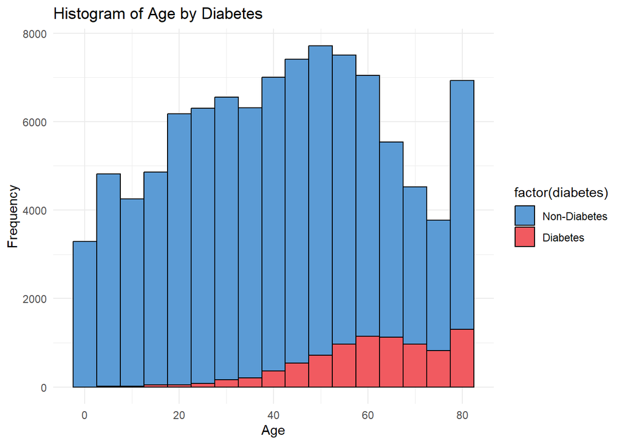

```r
# Histogram for age with diabetes vs. non-diabetes differentiation
ggplot(data, aes(x = age, fill = factor(diabetes))) +
  geom_histogram(binwidth = 5, color = "black") +
  scale_fill_manual(values = c("#5b9bd5", "#f15a60"), labels = c("Non-Diabetes", "Diabetes")) +
  labs(title = "Histogram of Age by Diabetes", x = "Age", y = "Frequency") +
  theme_minimal()
```

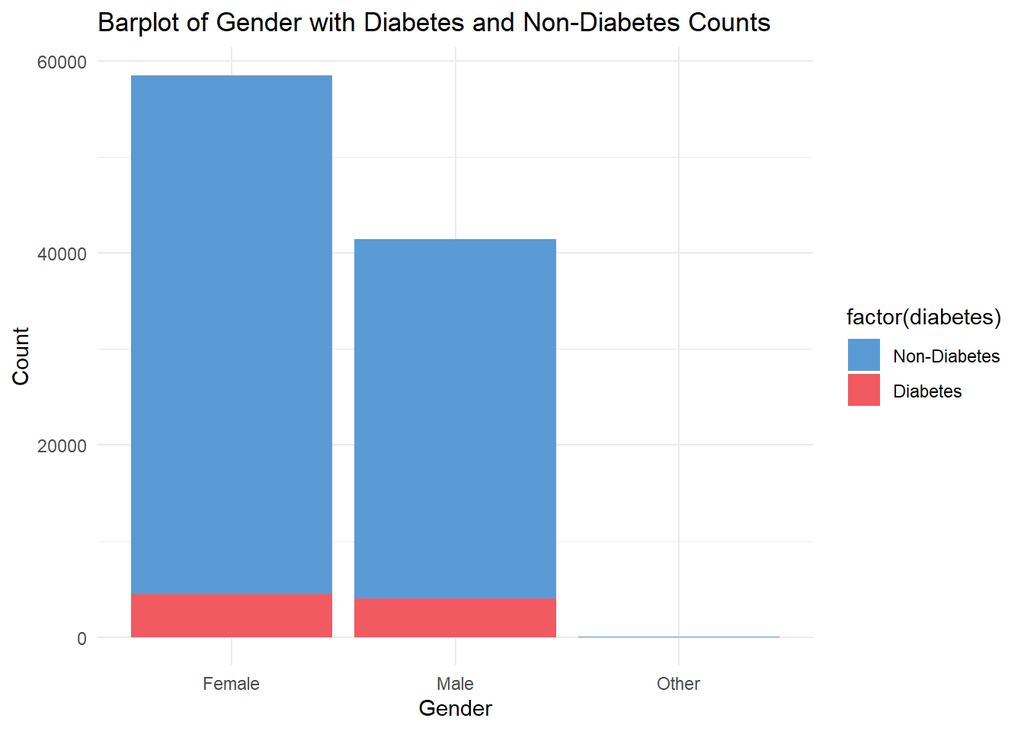

```r
# Barplot for gender
# Count diabetes and non-diabetes cases for each gender
gender_diabetes_count <- data %>%
  group_by(gender, diabetes) %>%
  summarise(count = n())
# Barplot showing diabetes and non-diabetes within each bar
ggplot(gender_diabetes_count, aes(x = gender, y = count, fill = factor(diabetes))) +
  geom_bar(stat = "identity", position = "stack") +
  scale_fill_manual(values = c("#5b9bd5", "#f15a60"), labels = c("Non-Diabetes", "Diabetes")) +
  labs(title = "Barplot of Gender with Diabetes and Non-Diabetes Counts", x = "Gender", y = "Count") +
  theme_minimal()
```

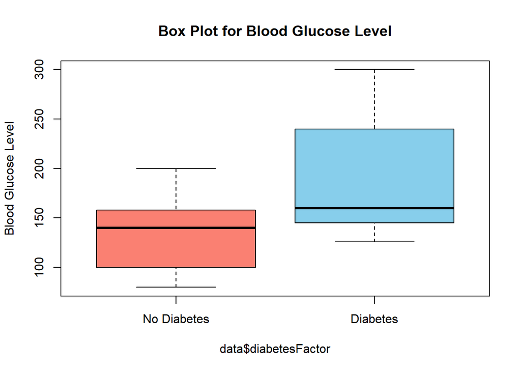

```r
# Separate data for diabetes and no diabetes
diabetes_data <- subset(data, diabetesFactor == 1)
no_diabetes_data <- subset(data, diabetesFactor == 0)

boxplot(data$blood_glucose_level ~ data$diabetesFactor,
        col = c("salmon", "skyblue"),
        names = c("No Diabetes", "Diabetes"),
        main = "Box Plot for Blood Glucose Level",
        ylab = "Blood Glucose Level")
```

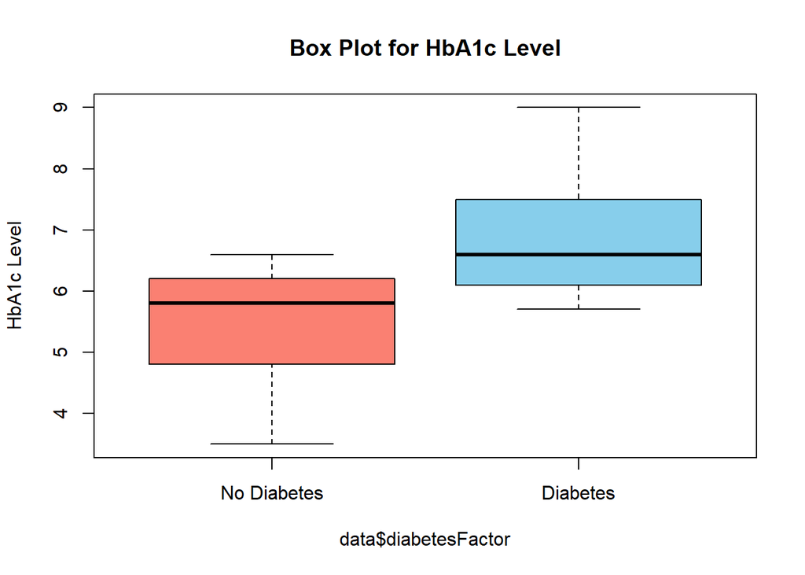

```r
boxplot(data$HbA1c_level ~ data$diabetesFactor,
        col = c("salmon", "skyblue"),
        names = c("No Diabetes", "Diabetes"),
        main = "Box Plot for HbA1c Level",
        ylab = "HbA1c Level")
```

#### Correlation Analysis

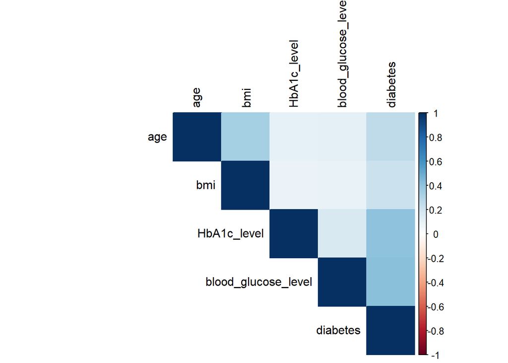

```r
# Create the correlation plot
cor_matrix <- cor(data[c("age", "bmi", "HbA1c_level", "blood_glucose_level","diabetes")])
corrplot(cor_matrix, method = "color", type = "upper", order = "hclust", tl.col = "black")
```

```r
# Print the numerical correlation matrix
print(cor_matrix)
```

```
##                           age        bmi HbA1c_level blood_glucose_level
## age                 1.0000000 0.33739578  0.10135366           0.1106723
## bmi                 0.3373958 1.00000000  0.08299716           0.0912614
## HbA1c_level         0.1013537 0.08299716  1.00000000           0.1667329
## blood_glucose_level 0.1106723 0.09126140  0.16673293           1.0000000
## diabetes            0.2580080 0.21435741  0.40066031           0.4195580
##                      diabetes
## age                 0.2580080
## bmi                 0.2143574
## HbA1c_level         0.4006603
## blood_glucose_level 0.4195580
## diabetes            1.0000000
```

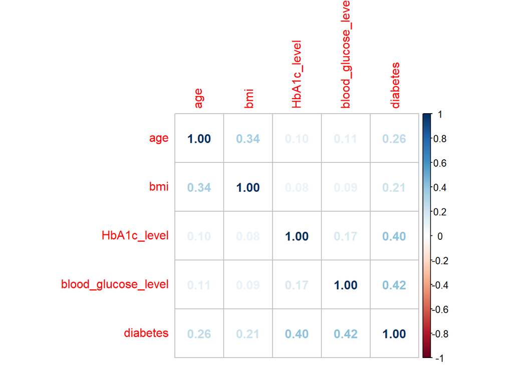

```r
# Plot correlation matrix with numbers
corrplot(cor_matrix, method = "number")
```

```r
# Pearson correlation coefficient
cor(cor_matrix, method = "pearson")
```

```
##                            age        bmi HbA1c_level blood_glucose_level
## age                  1.0000000  0.2209955  -0.4922078          -0.4747168
## bmi                  0.2209955  1.0000000  -0.5182682          -0.5045654
## HbA1c_level         -0.4922078 -0.5182682   1.0000000          -0.1804256
## blood_glucose_level -0.4747168 -0.5045654  -0.1804256           1.0000000
## diabetes            -0.3279523 -0.4251572   0.2308386           0.2779978
##                       diabetes
## age                 -0.3279523
## bmi                 -0.4251572
## HbA1c_level          0.2308386
## blood_glucose_level  0.2779978
## diabetes             1.0000000
```

#### Data Partition

```r
# Data Partition
set.seed(1234)
pd <- sample(2, nrow(data), replace = TRUE, prob = c(0.8, 0.2))
train_set <- data[pd == 1,]
test_set <- data[pd == 2,]
```

#### Decision Tree with party package

```r
# Decision tree with party
tree <- ctree(diabetesFactor~age+bmi+HbA1c_level+blood_glucose_level,data=train_set)
tree
```

```
##
##   Conditional inference tree with 35 terminal nodes
##
## Response:  diabetesFactor
## Inputs:  age, bmi, HbA1c_level, blood_glucose_level
## Number of observations:  80034
##
## 1) blood_glucose_level <= 200; criterion = 1, statistic = 14227.442
##   2) HbA1c_level <= 6.6; criterion = 1, statistic = 8731.579
##     3) age <= 54; criterion = 1, statistic = 1896.699
##       4) bmi <= 39.2; criterion = 1, statistic = 803.436
##         5) age <= 42; criterion = 1, statistic = 371.776
##           6) HbA1c_level <= 5; criterion = 1, statistic = 103.306
##             7)*  weights = 15521
##           6) HbA1c_level > 5
##             8) age <= 27; criterion = 1, statistic = 101.539
##               9) blood_glucose_level <= 100; criterion = 1, statistic = 18.412
##                 10)*  weights = 4103
##               9) blood_glucose_level > 100
##                 11) age <= 11; criterion = 0.988, statistic = 8.861
##                   12)*  weights = 3796
##                 11) age > 11
##                   13)*  weights = 5617
##             8) age > 27
##               14) bmi <= 30.66; criterion = 1, statistic = 63.403
##                 15) blood_glucose_level <= 100; criterion = 1, statistic = 16.744
##                   16)*  weights = 2206
##                 15) blood_glucose_level > 100
##                   17)*  weights = 4704
##               14) bmi > 30.66
##                 18) blood_glucose_level <= 100; criterion = 1, statistic = 19.515
##                   19)*  weights = 508
##                 18) blood_glucose_level > 100
##                   20)*  weights = 1154
##         5) age > 42
##           21) HbA1c_level <= 5; criterion = 1, statistic = 178.528
##             22)*  weights = 5115
##           21) HbA1c_level > 5
##             23) bmi <= 28.55; criterion = 1, statistic = 69.079
##               24) blood_glucose_level <= 100; criterion = 1, statistic = 27.537
```

[output cut: 55 more lines]

```
##         45) bmi > 32.73
##           61) blood_glucose_level <= 100; criterion = 1, statistic = 151.234
##             62)*  weights = 543
##           61) blood_glucose_level > 100
##             63) bmi <= 41.38; criterion = 1, statistic = 27.99
##               64) age <= 68; criterion = 0.987, statistic = 8.703
##                 65)*  weights = 989
##               64) age > 68
##                 66)*  weights = 493
##             63) bmi > 41.38
##               67)*  weights = 334
##   2) HbA1c_level > 6.6
##     68)*  weights = 1917
## 1) blood_glucose_level > 200
##   69)*  weights = 2645
```

[figure not shown]

```r
plot(tree)
```

```r
g <- recordPlot()
png("decision_tree.png")
replayPlot(g)
dev.off()
```

#### Tree pruning

```r
tree <- ctree(diabetesFactor~age+bmi+HbA1c_level+blood_glucose_level,data=train_set, controls=ctree_control(mincriterion = 0.99,minsplit = 2000))
tree
```

```
##
##   Conditional inference tree with 23 terminal nodes
##
## Response:  diabetesFactor
## Inputs:  age, bmi, HbA1c_level, blood_glucose_level
## Number of observations:  80034
##
## 1) blood_glucose_level <= 200; criterion = 1, statistic = 14227.442
##   2) HbA1c_level <= 6.6; criterion = 1, statistic = 8731.579
##     3) age <= 54; criterion = 1, statistic = 1896.699
##       4) bmi <= 39.2; criterion = 1, statistic = 803.436
##         5) age <= 42; criterion = 1, statistic = 371.776
##           6) HbA1c_level <= 5; criterion = 1, statistic = 103.306
##             7)*  weights = 15521
##           6) HbA1c_level > 5
##             8) age <= 27; criterion = 1, statistic = 101.539
##               9) blood_glucose_level <= 100; criterion = 1, statistic = 18.412
##                 10)*  weights = 4103
##               9) blood_glucose_level > 100
##                 11)*  weights = 9413
##             8) age > 27
##               12) bmi <= 30.66; criterion = 1, statistic = 63.403
##                 13) blood_glucose_level <= 100; criterion = 1, statistic = 16.744
##                   14)*  weights = 2206
##                 13) blood_glucose_level > 100
##                   15)*  weights = 4704
##               12) bmi > 30.66
##                 16)*  weights = 1662
##         5) age > 42
##           17) HbA1c_level <= 5; criterion = 1, statistic = 178.528
##             18)*  weights = 5115
##           17) HbA1c_level > 5
##             19) bmi <= 28.55; criterion = 1, statistic = 69.079
##               20) blood_glucose_level <= 100; criterion = 1, statistic = 27.537
##                 21)*  weights = 1512
##               20) blood_glucose_level > 100
##                 22)*  weights = 3597
##             19) bmi > 28.55
##               23) blood_glucose_level <= 100; criterion = 1, statistic = 33.739
##                 24)*  weights = 715
```

[output cut: 19 more lines]

```
##                 37)*  weights = 3656
##             34) bmi > 27.98
##               38) age <= 65; criterion = 1, statistic = 36.365
##                 39)*  weights = 973
##               38) age > 65
##                 40)*  weights = 1062
##         31) bmi > 32.73
##           41) blood_glucose_level <= 100; criterion = 1, statistic = 151.234
##             42)*  weights = 543
##           41) blood_glucose_level > 100
##             43)*  weights = 1816
##   2) HbA1c_level > 6.6
##     44)*  weights = 1917
## 1) blood_glucose_level > 200
##   45)*  weights = 2645
```

[figure not shown]

```r
plot(tree)
```

```r
g <- recordPlot()
png("pruned_decision_tree.png")
replayPlot(g)
dev.off()
```

#### Data Partition with rpart package

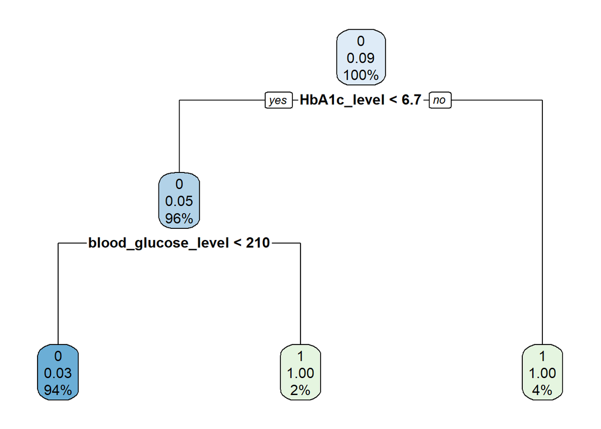

```r
# Decision tree with rpart

tree1 <-rpart(diabetesFactor~age+bmi+HbA1c_level+blood_glucose_level,data=train_set)
rpart.plot(tree1)
```

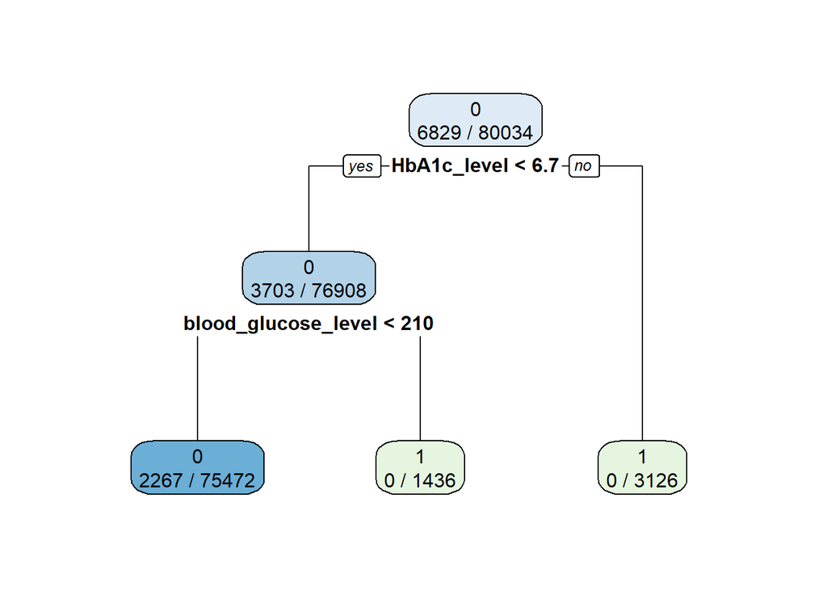

```r
rpart.plot(tree1, extra= 3)
```

#### Prediction

```r
#prediction
#predict(tree,test_set)

#Misclassification error for train data
tab <- table(predict(tree),train_set$diabetesFactor)
print(tab)
```

```
##
##         0     1
##   0 73205  2267
##   1     0  4562
```

```r
train_error <- 1-sum(diag(tab))/sum(tab)
#train_error

#Misclassification error for test data
testPred <- predict(tree, newdata=test_set)
tab <- table(testPred,test_set$diabetesFactor)
print(tab)
```

```
##
## testPred     0     1
##        0 18295   546
##        1     0  1125
```

```r
test_error <- 1-sum(diag(tab))/sum(tab)
#train_error
```

#### Performance Analysis

```
## Accuracy: 0.9726535
```

```
## Precision: 0.9710206
```

```
## Recall: 1
```

```
## F1-score: 0.9852973
```

```
## Misclassification Error for Train data : 0.02832546
```

```
## Misclassification Error for Test data: 0.02734649
```

## Conclusion

In this analysis, we performed a comprehensive exploration and prediction task using decision trees in R. We began by loading the dataset and gaining insights into its structure and summary statistics. The target variable, “diabetes,” was converted to a factor to facilitate classification tasks.

Next, we visualized the correlation between important features and the target variable using a correlation plot. This allowed us to identify potential relationships and understand feature importance.

To ensure robust model evaluation, we partitioned the data into training and testing sets and constructed decision trees using two different R packages: party and rpart. The party package was employed for conditional inference trees, while the rpart package used the CART algorithm.

Ultimately, the choice between using party and rpart decision trees depends on the specific requirements of the project, including the nature of the dataset and the desired level of model interpretability. We recommend further exploration and comparison of various decision tree algorithms and model evaluation techniques to identify the most suitable approach for your particular use case.

Overall, this analysis demonstrated the effectiveness of decision trees in diabetes prediction and provided valuable insights into the dataset’s underlying patterns. We encourage continued research and experimentation to optimize the model and further improve its predictive performance.